# Logistic regression analysis (week3)

## 3. Fitting a logistic regression model

```r
#A logistic regression model for predicting alcohol consumption (high vs low) with the chosen four predictors
m <- glm(high_use ~ failures + absences + studytime + G3, data = alc, family = "binomial")

# printing out the model summary
summary(m)
```

```
##
## Call:
## glm(formula = high_use ~ failures + absences + studytime + G3,
##     family = "binomial", data = alc)
##
## Deviance Residuals:
##     Min       1Q   Median       3Q      Max
## -2.5848  -0.8046  -0.6663   1.1027   2.2046
##
## Coefficients:
##             Estimate Std. Error z value Pr(>|z|)
## (Intercept) -0.43155    0.46417  -0.930 0.352522
## failures     0.34172    0.16495   2.072 0.038296 *
## absences     0.06262    0.01759   3.560 0.000371 ***
## studytime   -0.53006    0.15863  -3.341 0.000833 ***
## G3           0.01105    0.02852   0.388 0.698313
## ---
## Signif. codes:  0 '***' 0.001 '**' 0.01 '*' 0.05 '.' 0.1 ' ' 1
##
## (Dispersion parameter for binomial family taken to be 1)
##
##     Null deviance: 462.21  on 381  degrees of freedom
## Residual deviance: 423.47  on 377  degrees of freedom
## AIC: 433.47
##
## Number of Fisher Scoring iterations: 4
```

```r
#creating coefficients as odds ratios
OR <- coef(m) %>% exp

# computing confidence intervals for the odds ratios
CI <- confint(m) %>% exp
#combining and printing the ORs and CIs
cbind(OR, CI)
```

```
##                    OR     2.5 %    97.5 %
## (Intercept) 0.6495044 0.2590351 1.6065887
## failures    1.4073732 1.0190133 1.9541493
## absences    1.0646266 1.0308109 1.1041295
## studytime   0.5885684 0.4271793 0.7966834
## G3          1.0111158 0.9568568 1.0703968
```

```r
#testing: would G3 be significant as the only predictor
m2 <- glm(high_use ~ G3, data = alc, family = "binomial")
summary(m2) #no, not significant
```

```
##
## Call:
## glm(formula = high_use ~ G3, family = "binomial", data = alc)
##
## Deviance Residuals:
##     Min       1Q   Median       3Q      Max
## -0.8933  -0.8349  -0.8122   1.5495   1.6227
##
## Coefficients:
##             Estimate Std. Error z value Pr(>|z|)
## (Intercept) -0.71272    0.26843  -2.655  0.00793 **
## G3          -0.01621    0.02379  -0.681  0.49572
## ---
## Signif. codes:  0 '***' 0.001 '**' 0.01 '*' 0.05 '.' 0.1 ' ' 1
##
## (Dispersion parameter for binomial family taken to be 1)
##
##     Null deviance: 462.21  on 381  degrees of freedom
## Residual deviance: 461.75  on 380  degrees of freedom
## AIC: 465.75
##
## Number of Fisher Scoring iterations: 4
```

### 3.1 Interpreting the model:

**The summary shows that** three of the predictors significantly predict low vs. high alcohol use. Compared to those with low alcohol use, lower study time (p<.001), and more absences (p<.001) and class failures (p<.05) are more typical for those with high alcohol use. Final grade did not significantly differ between the alcohol use groups. Except for the grade variable the relations are as stated in the hypothesis.

**The odds ratios (OR) and their confidence intervals** show that, with 95% confidence, the odds ratio for…

- studytime is between 0.43-0.80
- absences is between 1.03 -1.10
- failures is between 1.02-1.95

### 3.2 The predictive power of a modified model

```r
#choosing the statistically significant variables from the first model, and making a new model with them
m_f <- glm(high_use ~ failures + absences + studytime, data = alc, family = "binomial")

#Exploring the predictive power of this modified model

# predicting the probability of high_use
probabilities <- predict(m_f, type = "response")

# adding the predicted probabilities to the data
alc <- mutate(alc, probability = probabilities)

#predicting high_use with the probabilities
alc <- mutate(alc, prediction = probability > 0.5)

select(alc, failures, absences, studytime, high_use, probability, prediction) %>% tail(10) #two misclassifications can be seen with these 10 observations (prediction based on model probabilities vs. actual high_use)
```

```
##     failures absences studytime high_use probability prediction
## 373        1        0         1    FALSE   0.3714011      FALSE
## 374        1       14         1     TRUE   0.5879619       TRUE
## 375        0        2         3    FALSE   0.1450987      FALSE
## 376        0        7         1    FALSE   0.4011299      FALSE
## 377        1        0         3    FALSE   0.1702142      FALSE
## 378        0        0         2    FALSE   0.2025250      FALSE
## 379        1        0         2    FALSE   0.2582354      FALSE
## 380        1        0         2    FALSE   0.2582354      FALSE
## 381        0        3         1     TRUE   0.3423836      FALSE
## 382        0        0         1     TRUE   0.3011900      FALSE
```

```r
# Creating a 2x2 cross tabulation of the target variable, i.e. actual case of high alcohol use, versus the predicted high vs. low use.
table(high_use = alc$high_use, prediction = alc$prediction) #This gives numbers
```

```
##         prediction
## high_use FALSE TRUE
##    FALSE   256   14
##    TRUE     89   23
```

```r
# The same tabulation but in percentages, and with error sums
table(high_use = alc$high_use, prediction = alc$prediction) %>% prop.table() %>% addmargins()
```

```
##         prediction
## high_use      FALSE       TRUE        Sum
##    FALSE 0.67015707 0.03664921 0.70680628
##    TRUE  0.23298429 0.06020942 0.29319372
##    Sum   0.90314136 0.09685864 1.00000000
```

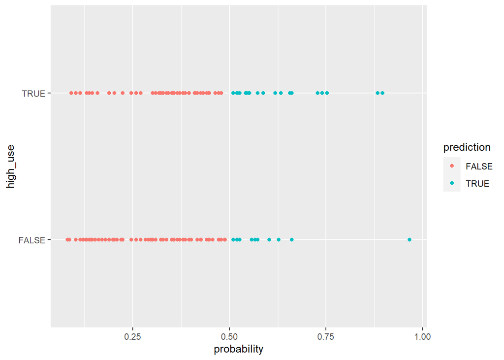

```r
# Making a plot to visualise the prediction accuracy (the false positives and false negatives that the model creates are colored with blue in the plot)
g <- ggplot(alc, aes(x = probability, y = high_use, col=prediction)) + geom_point()
g
```

```r
#computing the average number of incorrect predictions.
# 1) a loss function i.e. define mean prediction error
loss_func <- function(class, prob) {
  n_wrong <- abs(class - prob) > 0.5
  mean(n_wrong)
}
# 2)computing incorrectly classified cases for our model
loss_func(class = alc$high_use, prob = alc$probability) #27% cases incorrectly classified. This can also be obtained by combining the wrongly classified percentages from the cross-tabulation table (0.23 + 0.037)
```

```
## [1] 0.2696335
```

Based on the cross-tabulations of actual and predicted alcohol use class, and the value obtained from the loss_function, the model has an accuracy rate of (100-27) = 73%. This means that overall, 27% of cases are incorrectly classified into high or low consumption class. Since a random sorting (through numerous guesses) to these two classes would give an accuracy rate of 50%, the model seems to be an improvement to this.

### 3.3 Lastly, some cross-validation of the model

```r
# Performing a 10-fold cross-validation on the modified model
library(boot)
cv <- cv.glm(data = alc, cost = loss_func, glmfit = m_f, K = 10)
# average number of wrong predictions, i.e. prediction error (The cv.glm function saves the error in delta)
cv$delta[1]
```

```
## [1] 0.2774869
```

The model has a prediction error of 0.28, which is not smaller (better) than the one in DataCamp of 0.26.

Could I find a better model? Perhaps, by looking into all variable correlations with the alcohol use variable and choosing the ones that correlate with it the strongest. But how much better would this model be, it shall remain a mystery for now.